# 1-adni-nibabel-open-subject-018_S_4313

#### Nifti images features

(C) MK & ASL & AL

Created: 2019.11.08

Modified: 2019.11.13

The aim of this sciropt is acquire basic information about Nifti images with the use of Nibabel library. This is done for a number of Nifti images of subject 018_S_4313. The following operations are performed:

- loading Nifti header,
- loading data,
- displaying MIP image,
- comparition of Nifti header information.

All operations are undertaken for 6 different Nifti images: prepared from unprocessed DICOM data, downloaded from ADNI database and received from Sathies and Alexander:

1. **converted**
   1. 018_S_4313_c3d.nii,
   2. 018_S_4313_dcm2niix.nii,
   3. 018_S_4313_freesurfer.nii
2. **downloaded** from ADNI
   1. 018_S_4313_adni.nii - processed; downloaded as Nifi file (MT1__N3m)
3. **damaged**
   1. 018_S_4313_asl.nii - received from Alexander's 3.5" HD,
   2. 018_S_4313_sathiesh.nii - received from Sathiesh

```python
import os
import nibabel as nib
import matplotlib.pyplot as plt
```

###### Additional functions

```python
def info(img, name='image'):
    print(' {}: min={:.2f}, aver={:.2f},  max={:.2f}, \
shape={},dtype={}'.format(name, img.min(), img.mean(), img.max(), img.shape, img.dtype))
```

```python
def show_mips(img, title='image', figsize=(10,4)):
    plt.figure()
    for k in range(3):
        plt.subplot(1,3,k+1)
        plt.imshow(img.max(k), cmap='gray')
        plt.title('dir=%d' % k)
        plt.axis('off')
    plt.suptitle(title)
    plt.tight_layout()
```

```python
def text_wrap(fname = ''):
    """
    C: 2019.06.18
    M: 2019.06.22
    """
    if not len(fname):
        fname=os.path.basename(__file__)
    print()
    p = len(fname) + 8
    print(p * '#')
    print("### %s ###" % fname)
    print(p * '#')
```

###### Main script

```python
# A Main folder with all Nifit images
folder = os.path.join('/', 'media', 'mk', 'p1ext4', 'no19', 'adni', 'ADNI', '018_S_4313', 'all_nibabel-open')
os.chdir(folder)
print("Data folder:\n\t%s"  % os.getcwd())
```

```
Data folder:
	/media/mk/p1ext4/no19/adni/ADNI/018_S_4313/all_nibabel-open
```

```python
# Content of the working folder
for k, f in enumerate(os.listdir('.')):
    print(k,'-->', f)
```

```
0 --> 018_S_4313_adni.nii
1 --> 018_S_4313_asl.nii
2 --> 018_S_4313_sathiesh.nii
3 --> 018_S_4313_dcm2niix.nii
4 --> 018_S_4313_freesurfer.nii
5 --> 018_S_4313_c3d.nii
```

```python
# File names arranged manually
n1 = '018_S_4313_adni.nii'
n2 = '018_S_4313_c3d.nii'
n3 = '018_S_4313_dcm2niix.nii'
n4 = '018_S_4313_freesurfer.nii'
names = [n1, n2 , n3, n4]
labels = ['ADNI', 'C3D', 'DCM2NIIX', 'FREESURFER']

# broken images
n5 = '018_S_4313_asl.nii'
n6 = '018_S_4313_sathiesh.nii'
```

#### Access to Nifti header; load data and display 3 MIPs

##### ADNI

```
 ADNI: min=0.00, aver=275.41,  max=7437.58, shape=(170, 256, 256),dtype=>f4
```

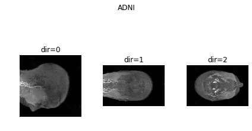

```python
name = 'ADNI'
nii1 = nib.load(n1)
im1 = nii1.get_data()
info(im1, name)
show_mips(im1, name, figsize = (10,4))
```

##### c3d

```
 c3d: min=0.00, aver=215.62,  max=5177.57, shape=(256, 256, 170),dtype=float32
```

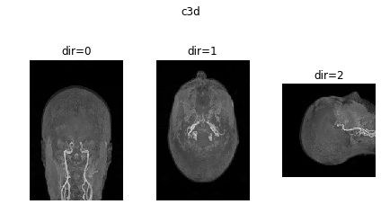

```python
name = 'c3d'
nii2 = nib.load(n2)
im2 = nii2.get_data()
info(im2, name)
show_mips(im2, name, figsize=(10,4))
```

##### dcm2niix

```
 dcm2niix: min=0.00, aver=146642.99,  max=3521190.25, shape=(170, 256, 256),dtype=float64
```

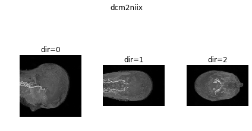

```python
name3 = 'dcm2niix'
nii3 = nib.load(n3)
im3 = nii3.get_data()
info(im3, name3)
show_mips(im3, name3, figsize=(10,4))
```

##### freesurfer

```
 freesurfer: min=0.00, aver=55.68,  max=1337.00, shape=(256, 256, 170),dtype=int16
```

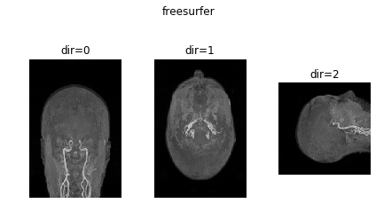

```python
name4 = 'freesurfer'
nii4 = nib.load(n4)
im4 = nii4.get_data()
info(im4, name4)
show_mips(im4, name4)
```

#### Print basic image information - comparision

```python
for k, n in enumerate(names):
    im = nib.load(n).get_data()
    info(im, labels[k])
```

```
 ADNI: min=0.00, aver=275.41,  max=7437.58, shape=(170, 256, 256),dtype=>f4
 C3D: min=0.00, aver=215.62,  max=5177.57, shape=(256, 256, 170),dtype=float32
 DCM2NIIX: min=0.00, aver=146642.99,  max=3521190.25, shape=(170, 256, 256),dtype=float64
 FREESURFER: min=0.00, aver=55.68,  max=1337.00, shape=(256, 256, 170),dtype=int16
```

#### Nifti headers - comparasion

```python
h1 = nib.load(n1).header
text_wrap(n1)
print(h1)
```

```
###########################
### 018_S_4313_adni.nii ###
###########################
<class 'nibabel.nifti1.Nifti1Header'> object, endian='>'
sizeof_hdr      : 348
data_type       : b''
db_name         : b'018_S_4313'
extents         : 0
session_error   : 0
regular         : b'r'
dim_info        : 0
dim             : [  3 170 256 256   1   1   1   1]
intent_p1       : 0.0
intent_p2       : 0.0
intent_p3       : 0.0
intent_code     : none
datatype        : float32
bitpix          : 32
slice_start     : 0
pixdim          : [1.  1.2 1.  1.  0.  0.  0.  0. ]
vox_offset      : 0.0
scl_slope       : nan
scl_inter       : nan
slice_end       : 0
slice_code      : unknown
xyzt_units      : 10
cal_max         : 0.0
cal_min         : 0.0
slice_duration  : 0.0
toffset         : 0.0
glmax           : 0
glmin           : 0
descrip         : b'MT1; N3m'
aux_file        : b''
qform_code      : aligned
sform_code      : aligned
quatern_b       : -0.09871419
quatern_c       : 0.05447772
quatern_d       : -0.005851536
qoffset_x       : -113.66935
qoffset_y       : -159.32535
qoffset_z       : -73.35881
srow_x          : [ 1.1927950e+00  8.7279646e-04  1.0941407e-01 -1.1366935e+02]
srow_y          : [-2.6860435e-02  9.8044252e-01  1.9552852e-01 -1.5932535e+02]
srow_z          : [ -0.12852427  -0.19680364   0.9745754  -73.35881   ]
intent_name     : b''
magic           : b'n+1'
```

```python
h2 = nib.load(n2).header
text_wrap(n2)
print(h2)
```

```
##########################
### 018_S_4313_c3d.nii ###
##########################
<class 'nibabel.nifti1.Nifti1Header'> object, endian='<'
sizeof_hdr      : 348
data_type       : b''
db_name         : b''
extents         : 0
session_error   : 0
regular         : b'r'
dim_info        : 0
dim             : [  3 256 256 170   1   1   1   1]
intent_p1       : 0.0
intent_p2       : 0.0
intent_p3       : 0.0
intent_code     : none
datatype        : float32
bitpix          : 32
slice_start     : 0
pixdim          : [1.       1.       1.       1.199997 0.       0.       0.       0.      ]
vox_offset      : 0.0
scl_slope       : nan
scl_inter       : nan
slice_end       : 0
slice_code      : unknown
xyzt_units      : 2
cal_max         : 0.0
cal_min         : 0.0
slice_duration  : 0.0
toffset         : 0.0
glmax           : 0
glmin           : 0
descrip         : b''
aux_file        : b''
qform_code      : aligned
sform_code      : scanner
quatern_b       : -0.5
quatern_c       : 0.5
quatern_d       : -0.5
qoffset_x       : -102.65392
qoffset_y       : 126.15098
qoffset_z       : 145.55853
srow_x          : [  -0.          0.          1.199997 -102.65392 ]
srow_y          : [ -1.       -0.       -0.      126.15098]
srow_z          : [  0.       -1.        0.      145.55853]
intent_name     : b''
magic           : b'n+1'
```

```python
h3 = nib.load(n3).header
text_wrap(n3)
print(h3)
```

```
###############################
### 018_S_4313_dcm2niix.nii ###
###############################
<class 'nibabel.nifti1.Nifti1Header'> object, endian='<'
sizeof_hdr      : 348
data_type       : b''
db_name         : b''
extents         : 0
session_error   : 0
regular         : b'r'
dim_info        : 54
dim             : [  3 170 256 256   1   1   1   1]
intent_p1       : 0.0
intent_p2       : 0.0
intent_p3       : 0.0
intent_code     : none
datatype        : int16
bitpix          : 16
slice_start     : 0
pixdim          : [1.       1.2      1.       1.       0.006771 0.       0.       0.      ]
vox_offset      : 0.0
scl_slope       : nan
scl_inter       : nan
slice_end       : 0
slice_code      : unknown
xyzt_units      : 10
cal_max         : 0.0
cal_min         : 0.0
slice_duration  : 0.0
toffset         : 0.0
glmax           : 0
glmin           : 0
descrip         : b'TE=3.1;Time=131021.890'
aux_file        : b''
qform_code      : scanner
sform_code      : scanner
quatern_b       : 0.0
quatern_c       : 0.0
quatern_d       : 0.0
qoffset_x       : -102.65392
qoffset_y       : -128.84903
qoffset_z       : -109.44147
srow_x          : [   1.199997    0.          0.       -102.65392 ]
srow_y          : [   0.         1.         0.      -128.84903]
srow_z          : [   0.         0.         1.      -109.44147]
intent_name     : b''
magic           : b'n+1'
```

```python
h4 = nib.load(n4).header
text_wrap(n4)
print(h4)
```

```
#################################
### 018_S_4313_freesurfer.nii ###
#################################
<class 'nibabel.nifti1.Nifti1Header'> object, endian='<'
sizeof_hdr      : 348
data_type       : b''
db_name         : b''
extents         : 0
session_error   : 0
regular         : b''
dim_info        : 0
dim             : [  3 256 256 170   1   1   1   1]
intent_p1       : 0.0
intent_p2       : 0.0
intent_p3       : 0.0
intent_code     : none
datatype        : int16
bitpix          : 16
slice_start     : 0
pixdim          : [1.       1.       1.       1.2      0.006771 1.       1.       1.      ]
vox_offset      : 0.0
scl_slope       : nan
scl_inter       : nan
slice_end       : 0
slice_code      : unknown
xyzt_units      : 10
cal_max         : 0.0
cal_min         : 0.0
slice_duration  : 0.0
toffset         : 0.0
glmax           : 0
glmin           : 0
descrip         : b'FreeSurfer Jan 18 2017'
aux_file        : b''
qform_code      : scanner
sform_code      : scanner
quatern_b       : -0.5
quatern_c       : 0.5
quatern_d       : -0.5
qoffset_x       : -102.65392
qoffset_y       : 126.15098
qoffset_z       : 145.55853
srow_x          : [  -0.        -0.         1.2     -102.65392]
srow_y          : [ -1.       -0.       -0.      126.15098]
srow_z          : [  0.       -1.        0.      145.55853]
intent_name     : b''
magic           : b'n+1'
```

#### An attempt to open "broken" files

##### Files from Alexander (018_S_4313_asl.nii) and Sathiesh (018_S_4313_sathiesh.nii)

```python
n5 = '018_S_4313_asl.nii'
n6 = '018_S_4313_sathiesh.nii'
```

```python
# loading the nii stucture - OK
nii5 = nib.load(n5) # OK
print(nii5.header) # OK
```

```
<class 'nibabel.nifti1.Nifti1Header'> object, endian='>'
sizeof_hdr      : 348
data_type       : b''
db_name         : b'018_S_4313'
extents         : 0
session_error   : 0
regular         : b'r'
dim_info        : 0
dim             : [  3 170 256 256   1   1   1   1]
intent_p1       : 0.0
intent_p2       : 0.0
intent_p3       : 0.0
intent_code     : none
datatype        : float32
bitpix          : 32
slice_start     : 0
pixdim          : [1.  1.2 1.  1.  0.  0.  0.  0. ]
vox_offset      : 0.0
scl_slope       : nan
scl_inter       : nan
slice_end       : 0
slice_code      : unknown
xyzt_units      : 10
cal_max         : 0.0
cal_min         : 0.0
slice_duration  : 0.0
toffset         : 0.0
glmax           : 0
glmin           : 0
descrip         : b'MT1; N3m'
aux_file        : b''
qform_code      : aligned
sform_code      : aligned
quatern_b       : -0.09871419
quatern_c       : 0.05447772
quatern_d       : -0.005851536
qoffset_x       : -113.66935
qoffset_y       : -159.32535
qoffset_z       : -73.35881
srow_x          : [ 1.1927950e+00  8.7279646e-04  1.0941407e-01 -1.1366935e+02]
srow_y          : [-2.6860435e-02  9.8044252e-01  1.9552852e-01 -1.5932535e+02]
srow_z          : [ -0.12852427  -0.19680364   0.9745754  -73.35881   ]
intent_name     : b''
magic           : b'n+1'
```

```python
# getting data
im5 = nii5.get_data() # ERROR
```

```
---------------------------------------------------------------------------
OSError                                   Traceback (most recent call last)
<ipython-input-23-d60a6b69c7b8> in <module>
      1 # getting data
----> 2 im5 = nii5.get_data() # ERROR

~/miniconda3/envs/py37/lib/python3.7/site-packages/nibabel/dataobj_images.py in get_data(self, caching)
    201         if self._data_cache is not None:
    202             return self._data_cache
--> 203         data = np.asanyarray(self._dataobj)
    204         if caching == 'fill':
    205             self._data_cache = data

~/miniconda3/envs/py37/lib/python3.7/site-packages/numpy/core/numeric.py in asanyarray(a, dtype, order)
    589
    590     """
--> 591     return array(a, dtype, copy=False, order=order, subok=True)
    592
    593

~/miniconda3/envs/py37/lib/python3.7/site-packages/nibabel/arrayproxy.py in __array__(self)
    353     def __array__(self):
    354         # Read array and scale
--> 355         raw_data = self.get_unscaled()
    356         return apply_read_scaling(raw_data, self._slope, self._inter)
    357

~/miniconda3/envs/py37/lib/python3.7/site-packages/nibabel/arrayproxy.py in get_unscaled(self)
    348                                        offset=self._offset,
    349                                        order=self.order,
--> 350                                        mmap=self._mmap)
    351         return raw_data
    352

~/miniconda3/envs/py37/lib/python3.7/site-packages/nibabel/volumeutils.py in array_from_file(shape, in_dtype, infile, offset, order, mmap)
    533                           n_bytes,
    534                           n_read,
--> 535                           getattr(infile, 'name', 'object')))
    536     arr = np.ndarray(shape, in_dtype, buffer=data_bytes, order=order)
    537     if needs_copy:

OSError: Expected 44564480 bytes, got 44499228 bytes from 018_S_4313_asl.nii
 - could the file be damaged?
```

##### File from Sathiesh (018_S_4313_sathiesh.nii)

```python
# loading a header - OK
nii6 = nib.load(n6)
hdr = nii6.header
print(hdr)
```

```
<class 'nibabel.nifti1.Nifti1Header'> object, endian='>'
sizeof_hdr      : 348
data_type       : b''
db_name         : b'018_S_4313'
extents         : 0
session_error   : 0
regular         : b'r'
dim_info        : 0
dim             : [  3 170 256 256   1   1   1   1]
intent_p1       : 0.0
intent_p2       : 0.0
intent_p3       : 0.0
intent_code     : none
datatype        : float32
bitpix          : 32
slice_start     : 0
pixdim          : [1.  1.2 1.  1.  0.  0.  0.  0. ]
vox_offset      : 0.0
scl_slope       : nan
scl_inter       : nan
slice_end       : 0
slice_code      : unknown
xyzt_units      : 10
cal_max         : 0.0
cal_min         : 0.0
slice_duration  : 0.0
toffset         : 0.0
glmax           : 0
glmin           : 0
descrip         : b'MT1; N3m'
aux_file        : b''
qform_code      : aligned
sform_code      : aligned
quatern_b       : -0.09871419
quatern_c       : 0.05447772
quatern_d       : -0.005851536
qoffset_x       : -113.66935
qoffset_y       : -159.32535
qoffset_z       : -73.35881
srow_x          : [ 1.1927950e+00  8.7279646e-04  1.0941407e-01 -1.1366935e+02]
srow_y          : [-2.6860435e-02  9.8044252e-01  1.9552852e-01 -1.5932535e+02]
srow_z          : [ -0.12852427  -0.19680364   0.9745754  -73.35881   ]
intent_name     : b''
magic           : b'n+1'
```

```python
# getting data
im6 = nii6.get_data() # ERROR
```

```
---------------------------------------------------------------------------
OSError                                   Traceback (most recent call last)
<ipython-input-26-522070550c53> in <module>
      1 # getting data
----> 2 im6 = nii6.get_data() # ERROR

~/miniconda3/envs/py37/lib/python3.7/site-packages/nibabel/dataobj_images.py in get_data(self, caching)
    201         if self._data_cache is not None:
    202             return self._data_cache
--> 203         data = np.asanyarray(self._dataobj)
    204         if caching == 'fill':
    205             self._data_cache = data

~/miniconda3/envs/py37/lib/python3.7/site-packages/numpy/core/numeric.py in asanyarray(a, dtype, order)
    589
    590     """
--> 591     return array(a, dtype, copy=False, order=order, subok=True)
    592
    593

~/miniconda3/envs/py37/lib/python3.7/site-packages/nibabel/arrayproxy.py in __array__(self)
    353     def __array__(self):
    354         # Read array and scale
--> 355         raw_data = self.get_unscaled()
    356         return apply_read_scaling(raw_data, self._slope, self._inter)
    357

~/miniconda3/envs/py37/lib/python3.7/site-packages/nibabel/arrayproxy.py in get_unscaled(self)
    348                                        offset=self._offset,
    349                                        order=self.order,
--> 350                                        mmap=self._mmap)
    351         return raw_data
    352

~/miniconda3/envs/py37/lib/python3.7/site-packages/nibabel/volumeutils.py in array_from_file(shape, in_dtype, infile, offset, order, mmap)
    533                           n_bytes,
    534                           n_read,
--> 535                           getattr(infile, 'name', 'object')))
    536     arr = np.ndarray(shape, in_dtype, buffer=data_bytes, order=order)
    537     if needs_copy:

OSError: Expected 44564480 bytes, got 44499228 bytes from 018_S_4313_sathiesh.nii
 - could the file be damaged?
```

**In both cases it is possible to read header information, but none of them can be loaded. The message suggests that "the file could be damaged".**